# EE106AHW7

```python
import numpy as np
from scipy import linalg
from scipy.integrate import odeint
import math
import matplotlib.pyplot as plt
import scipy.constants
```

```python
M = 1 #M is constant, and here just use theoretical units to cancel away its effect
R = 1 #constant radius of mass
L = 2 #must be more than R and constant; use next integer
g = scipy.constants.g
X_0 = [scipy.constants.pi/4, 0] #stationary, and let's just start halfway horizontal (pi/4)
Tx = 0
Ty = 10
```

```python
#PART D
tau = 0 #no torque so no input case
def state_eq(X,t, tau=0): #generalize with torque
    return [X[1], (-g*math.sin(X[0]))/R + tau/(M*R**2)]
```

```python
def free_simulation():
    global X
    global times
    times = np.linspace(0, 50, 10000)#long evolution
    X = odeint(state_eq, X_0,times)

    plt.plot(times, X[:, 0], label="theta (angle)")
    plt.plot(times, X[:, 1], label="omega (angular velocity)")
    plt.title("Evolution of pendulum with R=1, L=2, tau=0 and through times up till 50")
    plt.legend()
    plt.show()
```

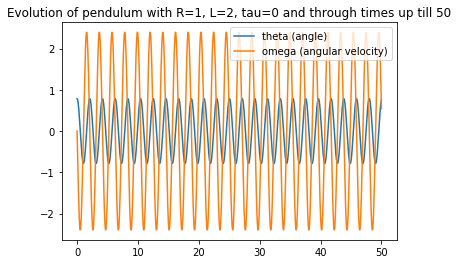

```python
#part d run
free_simulation()
```

As we can see, the angular velocity experiences much more amplitude than the angle (the radius can contribute to this, as well as the STARTING POSITION - MORE POTENTIAL ENERGY AT START)

```python
#part e
#Acceleration is just given by euler-lagrange
```

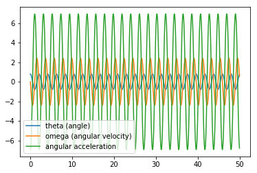

```python
angular_accel = [tau/(M*R**2) + (-g*math.sin(x))/R for x in X[:, 0]]
plt.plot(times, X[:, 0], label="theta (angle)")
plt.plot(times, X[:, 1], label="omega (angular velocity)")
plt.plot(times, angular_accel, label="angular acceleration")
plt.legend()
plt.show()
```

The behavior is like that of sine waves and their derivatives, as expected

```python
#part f (retrieval)
def position_from_state(thetas):
    x = [(Tx + L*math.sin(theta)) for theta in thetas]
    y = [(Ty - L*math.cos(theta)) for theta in thetas]
    return x, y
```

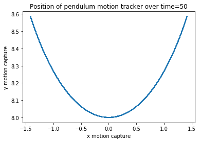

```python
#part g: plot
xs,ys = position_from_state(X[:,0])
plt.plot(xs, ys)
plt.title("Position of pendulum motion tracker over time=50")
plt.xlabel("x motion capture")
plt.ylabel("y motion capture")
plt.show()
```

As you can see, over this LONG time period I made (up to 50) with many oscillations, it does not form necessarily a perfect curve. However, this may be due to the numerical solver and gradual instability in the diffeq (e.g. making the Riemannian mesh finer in the numerical diffeq solver made it much more compact and stably represented across the many iterations). This is still for all purposes and intents legitimate and what a stable system should look like.

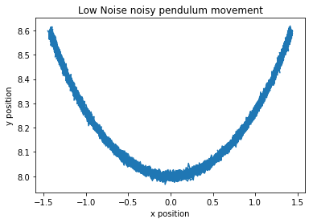

```python
#part h: ADD NOISE
#we should expect a LOT of deviance over the 50 time period
xnoise = np.random.normal(loc=xs,scale=0.01, size=len(xs))
ynoise = np.random.normal(loc=ys,scale=0.01, size=len(ys))
#LOW NOISE
plt.plot(xnoise, ynoise)
plt.title("Low Noise noisy pendulum movement")
plt.xlabel("x position")
plt.ylabel("y position")
plt.show()
```

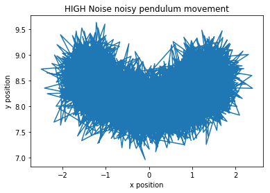

```python
xnoise = np.random.normal(loc=xs,scale=0.3, size=len(xs))
ynoise = np.random.normal(loc=ys,scale=0.3, size=len(ys))
#HIGH NOISE
plt.plot(xnoise, ynoise)
plt.title("HIGH Noise noisy pendulum movement")
plt.xlabel("x position")
plt.ylabel("y position")
plt.show()
```

As you can see on the order of 0.3 the radius, we start to get really wacky paths over t=50. This is very unlikely unless the string is unstable and elastic, etc. The original path is basically COMPLETELY obfuscated

```python
#PART I LAST PART!!
theta_d = 0 #(i.e. STOP IT and move it into EQUILLIBRIUM)
alpha = 2.5
beta = 10
```

```python
def state_eq(X,t, nonzerotorque = False): #generalize with torque GENERALIZED FOR PART I TO INCLUDE VARIABLE TORQUES
    if nonzerotorque:
        tau = -M*R**2*(alpha*(X[0]-theta_d) + beta*X[1])
    else:
        tau = 0

    return [X[1], (-g*math.sin(X[0]))/R + tau/(M*R**2)]
```

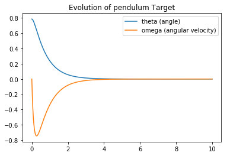

```python
times = np.linspace(0, 10, 10000)#long evolution
X = odeint(state_eq, X_0, times, args=(True,))

plt.plot(times, X[:, 0], label="theta (angle)")
plt.plot(times, X[:, 1], label="omega (angular velocity)")
plt.title("Evolution of pendulum Target")
plt.legend()
plt.show()
```

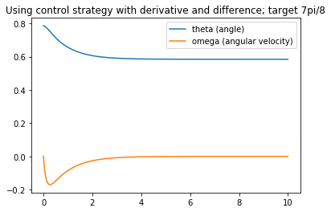

```python
#2 - NOT TOO SHABBY OF A CONTROLLER!
theta_d = scipy.constants.pi*7/8
times = np.linspace(0, 10, 10000)#long evolution
X = odeint(state_eq, X_0, times, args=(True,))

plt.plot(times, X[:, 0], label="theta (angle)")
plt.plot(times, X[:, 1], label="omega (angular velocity)")
plt.title("Using control strategy with derivative and difference; target 7pi/8")
plt.legend()
plt.show()
```